# Biostat III exercises in R

## Laboratory exercise 28

Flexible parametric models (fpm) implemented in Stata (stpm2) and R (rstpm2).

One difference: Restricted cubic splines using truncated power basis (stpm2, Stata) using B-spline basis (rstpm2, R).

### Suggested solutions by

Authors: Xing-Rong Liu and Mark Clements, 2016-03-06

You may have to install the required packages the first time you use them. You can install a package by `install.packages("package_of_interest")` for each package you require.

```r
require(rstpm2)  # for the flexible parametric model
require(foreign) # needed to read data set from Stata
require(dplyr)   # for data manipulation
```

We start by reading the data and then define a 1/0 varible for the events that we are interested in.

```r
melanoma <- read.dta("http://biostat3.net/download/melanoma.dta")

## Extract subset and create 0/1 outcome variables
melanoma0 <- melanoma %>% filter(stage=="Localised") %>%
             mutate(event = ifelse(status=="Dead: cancer" & surv_mm<120, 1, 0),
                    time = pmin(120, surv_mm)/12,
                    agegrp1 = ifelse(agegrp=="0-44", 1, 0),  # used by time-dependent effect
                    agegrp2 = ifelse(agegrp=="45-59", 1, 0), # used by time-dependent effect
                    agegrp3 = ifelse(agegrp=="60-74", 1, 0), # used by time-dependent effect
                    agegrp4 = ifelse(agegrp=="75+", 1, 0))   # used by time-dependent effect
```

**(a)** Flexible parametric model with df=4.

```r
## (a) Flexible parametric model with df=4
fpma <- stpm2(Surv(time,event) ~ year8594, data=melanoma0, df=4)
beta <- as.numeric(coef(fpma)[2])
se <- as.numeric(sqrt(fpma@vcov[2,2]))      # standard error of beta
confin <- c(beta - 1.96*se, beta + 1.96*se) # 95% confidence interval of log(HR)
p_value <- 1-pchisq((beta/se)^2, 1)         # Wald-type test of beta

## Summaries of Beta and HR
cbind(beta = beta, se = se, z = beta/se, p_value = p_value)
```

```
##            beta         se         z      p_value
## [1,] -0.2433363 0.06584011 -3.695867 0.0002191374
```

```r
cbind(HR = exp(beta), lower.95 = exp(confin)[1], upper.95 =  exp(confin)[2])
```

```
##             HR  lower.95  upper.95
## [1,] 0.7840078 0.6890903 0.8919995
```

Making a cox model for comparison.

```r
cox <- coxph(Surv(time, event) ~ year8594,
             data=melanoma0) # year8594 is a categorical variable
summary(cox)
```

```
## Call:
## coxph(formula = Surv(time, event) ~ year8594, data = melanoma0)
##
##   n= 5318, number of events= 960
##
##                             coef exp(coef) se(coef)      z Pr(>|z|)
## year8594Diagnosed 85-94 -0.25297   0.77649  0.06579 -3.845 0.000121 ***
## ---
## Signif. codes:  0 '***' 0.001 '**' 0.01 '*' 0.05 '.' 0.1 ' ' 1
##
##                         exp(coef) exp(-coef) lower .95 upper .95
## year8594Diagnosed 85-94    0.7765      1.288    0.6825    0.8834
##
## Concordance= 0.533  (se = 0.008 )
## Rsquare= 0.003   (max possible= 0.949 )
## Likelihood ratio test= 14.83  on 1 df,   p=0.0001177
## Wald test            = 14.78  on 1 df,   p=0.0001206
## Score (logrank) test = 14.86  on 1 df,   p=0.000116
```

The hazard ratio, 95% confidence interval and statistical significance are very similar to the Cox model.

**(b)** Prediction and plots of survival and hazard by calendar period.

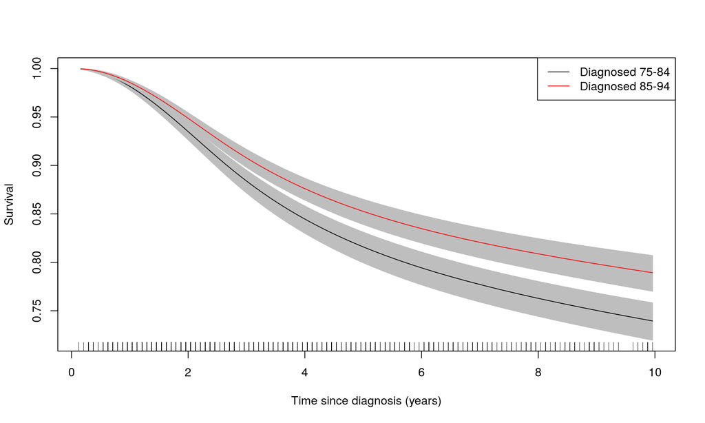

```r
## (b) Prediction and plots of survival and hazard by calendar period
years <- levels(melanoma0$year8594)
alegend <- function() legend("topright", legend=years, col=1:2, lty=1)

plot(fpma,newdata=data.frame(year8594=years[1]),
     xlab="Time since diagnosis (years)")
plot(fpma,newdata=data.frame(year8594=years[2]), add=TRUE, ci=TRUE,
     line.col=2)
alegend()
```

Localised skin melanoma. Predicted survival functions from a exible parametric model.

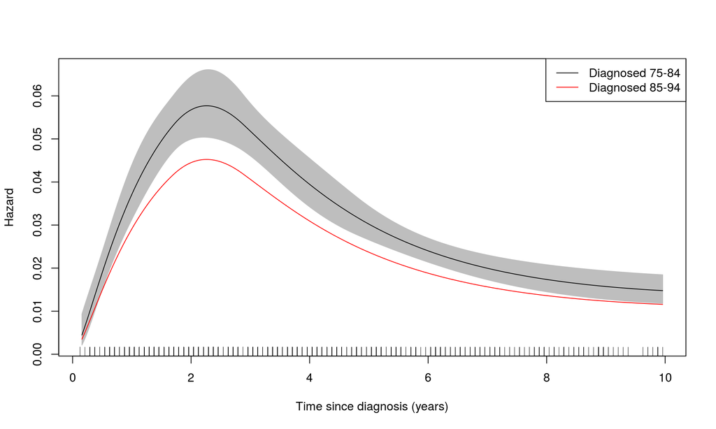

```r
plot(fpma,newdata=data.frame(year8594=years[1]), type="haz",
     xlab="Time since diagnosis (years)", ylab="Hazard")
plot(fpma,newdata=data.frame(year8594=years[2]), type="haz", add=TRUE,
     line.col=2)
alegend()
```

Localised skin melanoma. Predicted hazard functions from a exible parametric model.

**(c)** Plotting the hazards on the log scale. There is a constant difference as the predictions are from a proportional hazards model and a multiplicative effect becomes additive on the log scale.

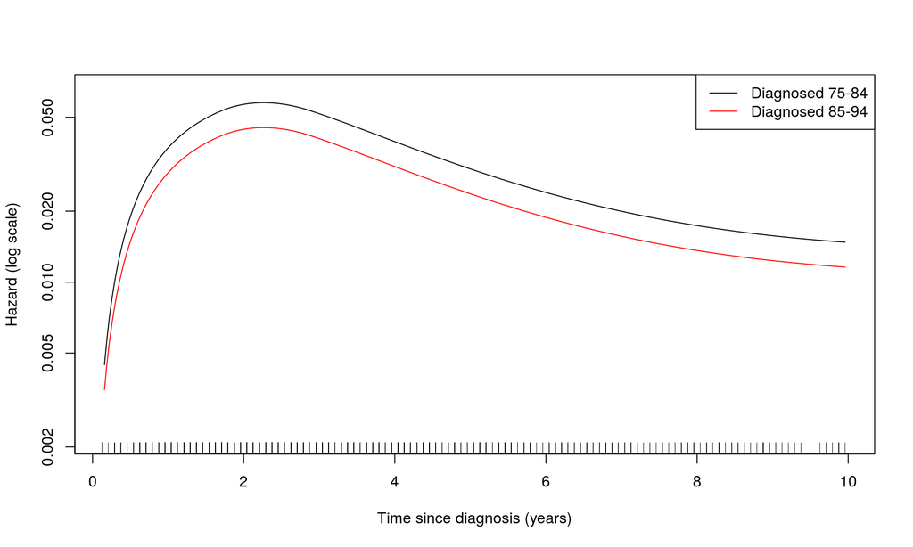

```r
## (c) hazards on log scale, adding log="y"
plot(fpma,newdata=data.frame(year8594=years[1]), type="haz",
     xlab="Time since diagnosis (years)", log="y", ci=FALSE,
     ylab="Hazard (log scale)")

plot(fpma,newdata=data.frame(year8594=years[2]), type="haz",
     add=TRUE, line.col=2)
alegend()
```

Localised skin melanoma. Predicted hazard functions on log scale from a exible parametric model.

**(d)** Investigate DF for the baseline with criteria AIC and BIC.

```r
summary(fpma)
```

```
## Maximum likelihood estimation
##
## Call:
## mle2(minuslogl = negll, start = coef, eval.only = TRUE, vecpar = TRUE,
##     gr = function (beta, kappa = 1)
##     {
##         if (interval)
##             stop("Gradient not implemented for interval-censored data.")
##         localargs <- args
##         localargs$kappa <- kappa
##         localargs$return_type <- "gradient"
##         return(.Call("model_output", localargs, package = "rstpm2"))
##     }, control = list(parscale = c(1, 1, 1, 1, 1, 1), maxit = 300),
##     lower = -Inf, upper = Inf)
##
## Coefficients:
##                         Estimate Std. Error  z value     Pr(z)
## (Intercept)             -8.68011    0.58362 -14.8730 < 2.2e-16 ***
## year8594Diagnosed 85-94 -0.24334    0.06584  -3.6959 0.0002191 ***
## nsx(log(time), df = 4)1  6.58737    0.57687  11.4192 < 2.2e-16 ***
## nsx(log(time), df = 4)2  5.65891    0.38069  14.8648 < 2.2e-16 ***
## nsx(log(time), df = 4)3 11.41694    1.14339   9.9851 < 2.2e-16 ***
## nsx(log(time), df = 4)4  4.93069    0.24526  20.1043 < 2.2e-16 ***
## ---
## Signif. codes:  0 '***' 0.001 '**' 0.01 '*' 0.05 '.' 0.1 ' ' 1
##
## -2 log L: 8440.488
```

```r
aicc <- bicc <- beta <- se <- rep(NULL,6)
BIC <- function(object, nknots){
    -2 * as.numeric(bbmle::logLik(object)) + log(sum(melanoma0$event)) * (1 + nknots)
}

for (i in 1:6 ) {
  fitaic <- stpm2(Surv(time, event) ~ year8594, data=melanoma0, df=i)
  aicc[i] <- AIC(fitaic)
  bicc[i] <- BIC(fitaic, i)
  beta[i] <- as.numeric(coef(fitaic)[2])
  se[i] <- as.numeric(sqrt(fitaic@vcov[2,2]))
}
rbind(beta=beta, se=se, aicc=aicc, bicc=bicc)
```

```
##               [,1]          [,2]          [,3]          [,4]          [,5]
## beta   -0.11575120   -0.23959859   -0.24389286   -0.24333629   -0.24554505
## se      0.06575706    0.06584092    0.06581083    0.06584011    0.06580441
## aicc 8676.81191687 8452.82834577 8452.43320118 8452.48836681 8447.41676243
## bicc 8684.54578344 8465.42914562 8469.90093431 8474.82303323 8474.61836214
##               [,6]
## beta   -0.24600362
## se      0.06580314
## aicc 8447.71022014
## bicc 8479.77875313
```

The log hazard ratios (and hence the hazard ratios) from 2 df and up are similar and for 3 df they are very similar. The main difference is for 1 df, which is equivalent to a Weibull model. The Weibull model enforces a monotonic hazard function and as the hazard function in the melanoma data has a turning point it is clearly inappropriate.

**(e)** Plots of predicted baseline survivals and hazards with df=1:6.

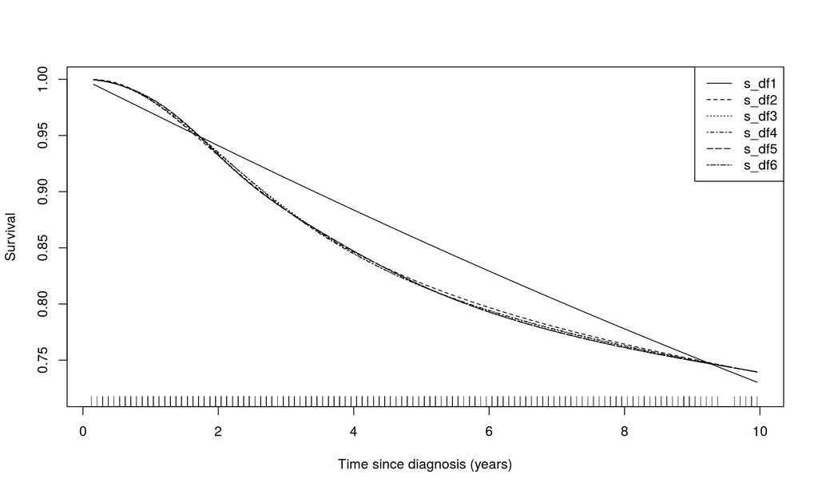

```r
## Baseline survival
fitaic0 <- stpm2(Surv(time, event) ~ year8594, data=melanoma0, df=6)
plot(fitaic0,newdata=data.frame(year8594=years[1]), lty=6, ci=F,
     xlab="Time since diagnosis (years)")

dfs <- c("s_df1","s_df2","s_df3","s_df4","s_df5","s_df6")
for (i in 1:5 ) {
  fitaic <- stpm2(Surv(time, event) ~ year8594, data=melanoma0, df=i)
  plot(fitaic,newdata=data.frame(year8594=years[1]), add=TRUE,lty=i,
       xlab="Time since diagnosis (years)")
}
legend("topright", legend=dfs[1:6], lty=1:6)
```

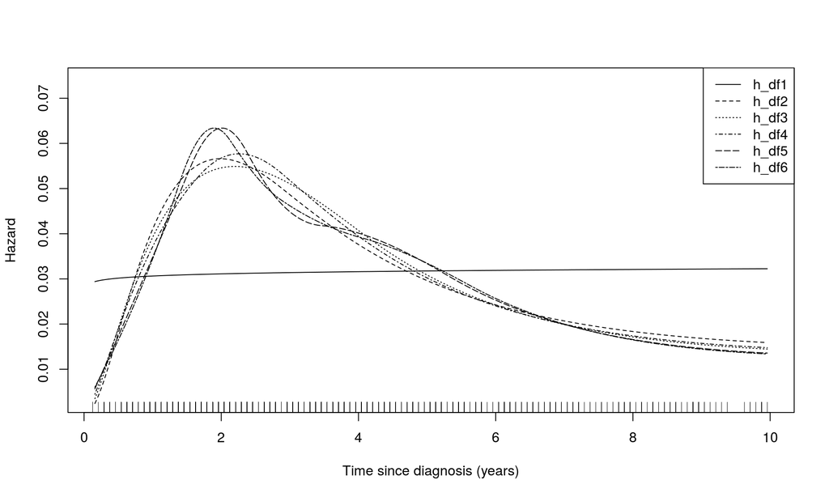

```r
## Baseline hazard
fitaic1 <- stpm2(Surv(time, event) ~ year8594, data=melanoma0, df=6)
plot(fitaic1,newdata=data.frame(year8594=years[1]), lty=6, type="haz",
     ci=F, xlab="Time since diagnosis (years)", ylab="Hazard")

for (i in 1:5 ) {
  fitaic <- stpm2(Surv(time, event) ~ year8594, data=melanoma0, df=i)
  plot(fitaic,newdata=data.frame(year8594=years[1]), add=TRUE, lty=i,
       type="haz", xlab="Time since diagnosis (years)", ylab="Hazard")
}
dfs2 <- c("h_df1","h_df2","h_df3","h_df4","h_df5","h_df6")
legend("topright", legend=dfs2[1:6], lty=1:6)
```

With the exception of 1 df (the Weibull model), the survival and hazard functions show similar shapes, so as long we have enough knots our conclusions would be very similar.

**(f)** Adjust for sex and age (in categories).

```r
fpmf <- stpm2(Surv(time, event) ~ sex + year8594 + agegrp,
              data=melanoma0, df=4)

beta <- coef(fpmf)[2:6] ## log(HR)
se <- sqrt(diag(fpmf@vcov[2:6,2:6]))            # standard errors of beta
z <- beta/se                                    # z-scores
confin <- cbind(beta - 1.96*se, beta + 1.96*se) # 95% confidence interval of beta=log(HR)
p_value <- 1-pchisq((beta/se)^2, 1)             # Wald-type test of beta

## Summaries of Beta and HR
cbind(beta = beta, se = se, z = beta/se, p_value = p_value) # summaries of beta
```

```
##                               beta         se         z      p_value
## sexFemale               -0.5315676 0.06545328 -8.121329 4.440892e-16
## year8594Diagnosed 85-94 -0.3240732 0.06623450 -4.892816 9.940347e-07
## agegrp45-59              0.2835336 0.09417351  3.010758 2.605967e-03
## agegrp60-74              0.6216986 0.09087777  6.841041 7.861933e-12
## agegrp75+                1.2238357 0.10445135 11.716802 0.000000e+00
```

```r
cbind(HR = exp(beta), lower.95 = exp(confin)[,1], upper.95 =  exp(confin)[,2])
```

```
##                                HR  lower.95  upper.95
## sexFemale               0.5876830 0.5169257 0.6681255
## year8594Diagnosed 85-94 0.7231973 0.6351508 0.8234491
## agegrp45-59             1.3278135 1.1040150 1.5969790
## agegrp60-74             1.8620883 1.5582730 2.2251382
## agegrp75+               3.4002050 2.7707307 4.1726877
```

```r
## To test the joint significance of categorized age with Wald-type test
## Joint H0:
##          beta_(agegrp45-59) = 0
##          beta_(agegrp60-74) = 0
##          beta_(agegrp75+) = 0
statistic <- t(coef(fpmf)[4:6]) %*% solve(vcov(fpmf)[4:6,4:6]) %*% coef(fpmf)[4:6]
p_value <- 1 - pchisq(statistic, 3)
cbind(chi2_statistics =statistic, P_value = p_value)
```

```
##          [,1] [,2]
## [1,] 155.7851    0
```

```r
## To test the overall effect of age with LR test
fpmf2 <- stpm2(Surv(time,event) ~ sex + year8594 , data=melanoma0, df=4)
anova(fpmf, fpmf2)
```

```
## Likelihood Ratio Tests
## Model 1: fpmf, [negll]: (Intercept)+sexFemale+year8594Diagnosed 85-94+
##           agegrp45-59+agegrp60-74+agegrp75++nsx(log(time), df = 4)1+
##           nsx(log(time), df = 4)2+nsx(log(time), df = 4)3+nsx(log(time),
##           df = 4)4
## Model 2: fpmf2, [negll]: (Intercept)+sexFemale+year8594Diagnosed 85-94+
##           nsx(log(time), df = 4)1+nsx(log(time), df = 4)2+nsx(log(time),
##           df = 4)3+nsx(log(time), df = 4)4
##   Tot Df Deviance  Chisq Df Pr(>Chisq)
## 1     10   8241.3
## 2      7   8385.9 144.56  3  < 2.2e-16 ***
## ---
## Signif. codes:  0 '***' 0.001 '**' 0.01 '*' 0.05 '.' 0.1 ' ' 1
```

The estimates are similar to those obtained from the Cox model. The Wald test yields a very highly significant result, which is similar to that obtained from the comparable test for the Cox model.

**(h)** Change to time-varying effect of agegrp2:4.

```r
## (h) Change to time-varying effect of agegrp2:4
## NB: including main effect of agerp
fpmh <- stpm2(Surv(time,event) ~ sex + year8594 + agegrp2 + agegrp3 + agegrp4,
              data=melanoma0, tvc=list(agegrp2 = 2, agegrp3 = 2, agegrp4 = 2),
              smooth.formula=~ nsx(log(time),df=4)  )
## NB: no main effect of agegrp
fpmh1 <- stpm2(Surv(time,event) ~ sex + year8594 ,
               data=melanoma0, tvc=list(agegrp2 = 2, agegrp3 = 2, agegrp4 = 2),
               smooth.formula=~ nsx(log(time),df=4)  )

beta <- coef(fpmh)[2:6] ## log(HR)
se <- sqrt(diag(fpmh@vcov[2:6,2:6])) ## standard errors of beta
z <- beta/se ## z-scores
confin <- cbind(beta - 1.96*se, beta + 1.96*se) ## 95% confidence interval of beta=log(HR)
p_value <- 1-pchisq((beta/se)^2, 1) ## Wald-type test of beta

## Summaries of Beta and HR
cbind(beta = beta, se = se, z = beta/se, p_value = p_value) ## summaries of beta
```

```
##                               beta         se         z      p_value
## sexFemale               -0.5257152 0.06542329 -8.035597 8.881784e-16
## year8594Diagnosed 85-94 -0.3282799 0.06631778 -4.950105 7.417363e-07
## agegrp2                  1.8952278 1.45209452  1.305168 1.918355e-01
## agegrp3                  1.6720363 1.40055220  1.193841 2.325403e-01
## agegrp4                  5.2026583 1.35763778  3.832140 1.270333e-04
```

```r
cbind(HR = exp(beta), lower.95 = exp(confin)[,1], upper.95 =  exp(confin)[,2])
```

```
##                                  HR   lower.95     upper.95
## sexFemale                 0.5911324  0.5199905    0.6720077
## year8594Diagnosed 85-94   0.7201614  0.6323813    0.8201262
## agegrp2                   6.6540640  0.3864018  114.5868508
## agegrp3                   5.3229959  0.3419653   82.8571960
## agegrp4                 181.7547617 12.7010957 2600.9404444
```

```r
## LR test comparing fpmh (non-PH for agegrp2:4) with fpmf(PH for agegrp2:4)
anova(fpmh, fpmf)
```

```
## Likelihood Ratio Tests
## Model 1: fpmh, [negll]: (Intercept)+sexFemale+year8594Diagnosed 85-94+
##           agegrp2+agegrp3+agegrp4+nsx(log(time), df = 4)1+
##           nsx(log(time), df = 4)2+nsx(log(time), df = 4)3+nsx(log(time),
##           df = 4)4+agegrp2:nsx(log(time), df = 2)1+
##           agegrp2:nsx(log(time), df = 2)2+agegrp3:nsx(log(time), df =
##           2)1+agegrp3:nsx(log(time), df = 2)2+agegrp4:nsx(log(time), df
##           = 2)1+agegrp4:nsx(log(time), df = 2)2
## Model 2: fpmf, [negll]: (Intercept)+sexFemale+year8594Diagnosed 85-94+
##           agegrp45-59+agegrp60-74+agegrp75++nsx(log(time), df = 4)1+
##           nsx(log(time), df = 4)2+nsx(log(time), df = 4)3+nsx(log(time),
##           df = 4)4
##   Tot Df Deviance  Chisq Df Pr(>Chisq)
## 1     16   8212.1
## 2     10   8241.3 29.271  6  5.406e-05 ***
## ---
## Signif. codes:  0 '***' 0.001 '**' 0.01 '*' 0.05 '.' 0.1 ' ' 1
```

```r
anova(fpmh1, fpmf)
```

```
## Likelihood Ratio Tests
## Model 1: fpmh1, [negll]: (Intercept)+sexFemale+year8594Diagnosed 85-94+
##           nsx(log(time), df = 4)1+nsx(log(time), df = 4)2+nsx(log(time),
##           df = 4)3+nsx(log(time), df = 4)4+agegrp2:nsx(log(time), df =
##           2)1+agegrp2:nsx(log(time), df = 2)2+nsx(log(time), df =
##           2)1:agegrp3+nsx(log(time), df = 2)2:agegrp3+nsx(log(time), df
##           = 2)1:agegrp4+nsx(log(time), df = 2)2:agegrp4
## Model 2: fpmf, [negll]: (Intercept)+sexFemale+year8594Diagnosed 85-94+
##           agegrp45-59+agegrp60-74+agegrp75++nsx(log(time), df = 4)1+
##           nsx(log(time), df = 4)2+nsx(log(time), df = 4)3+nsx(log(time),
##           df = 4)4
##   Tot Df Deviance  Chisq Df Pr(>Chisq)
## 1     13   8237.3
## 2     10   8241.3 4.0156  3     0.2598
```

```r
## I investigated the non-proportional effect of age with penalized models
## here, sp is the optimal smoothing parameters estimated from models without sp argument
pfit0 <- pstpm2(Surv(time,event) ~ sex + year8594 + agegrp2 + agegrp3 + agegrp4,
                smooth.formula=~s(log(time)), data=melanoma0, sp=0.1359685)

## The time-dependent effects including linear forms of age groups
pfit1 <- pstpm2(Surv(time,event) ~ sex + year8594,
                smooth.formula=~s(log(time)) + s(log(time),by=agegrp2) +
                                s(log(time),by=agegrp3) + s(log(time),by=agegrp4),
                data=melanoma0, sp=c( 0.1429949, 1.6133966, 1.3183117, 1.9958815))
anova(pfit1, pfit0)## the results also suggest there is strong evidence
```

```
## Likelihood Ratio Tests
## Model 1: pfit1, [negll]: (Intercept)+sexFemale+year8594Diagnosed 85-94+
##           s(log(time)).1+s(log(time)).2+s(log(time)).3+s(log(time)).4+
##           s(log(time)).5+s(log(time)).6+s(log(time)).7+s(log(time)).8+
##           s(log(time)).9+s(log(time)):agegrp2.1+s(log(time)):agegrp2.2+
##           s(log(time)):agegrp2.3+s(log(time)):agegrp2.4+
##           s(log(time)):agegrp2.5+s(log(time)):agegrp2.6+
##           s(log(time)):agegrp2.7+s(log(time)):agegrp2.8+
##           s(log(time)):agegrp2.9+s(log(time)):agegrp2.10+
##           s(log(time)):agegrp3.1+s(log(time)):agegrp3.2+
##           s(log(time)):agegrp3.3+s(log(time)):agegrp3.4+
##           s(log(time)):agegrp3.5+s(log(time)):agegrp3.6+
##           s(log(time)):agegrp3.7+s(log(time)):agegrp3.8+
##           s(log(time)):agegrp3.9+s(log(time)):agegrp3.10+
##           s(log(time)):agegrp4.1+s(log(time)):agegrp4.2+
##           s(log(time)):agegrp4.3+s(log(time)):agegrp4.4+
##           s(log(time)):agegrp4.5+s(log(time)):agegrp4.6+
##           s(log(time)):agegrp4.7+s(log(time)):agegrp4.8+
##           s(log(time)):agegrp4.9+s(log(time)):agegrp4.10
## Model 2: pfit0, [negll]: (Intercept)+sexFemale+year8594Diagnosed 85-94+
##           agegrp2+agegrp3+agegrp4+s(log(time)).1+s(log(time)).2+
##           s(log(time)).3+s(log(time)).4+s(log(time)).5+s(log(time)).6+
##           s(log(time)).7+s(log(time)).8+s(log(time)).9
##   Tot Df Deviance  Chisq     Df Pr(>Chisq)
## 1 16.394   8219.1
## 2 11.701   8240.9 21.718 4.6929  0.0004482 ***
## ---
## Signif. codes:  0 '***' 0.001 '**' 0.01 '*' 0.05 '.' 0.1 ' ' 1
```

There is strong evidence of a non-proportional effect of age.

**(i)** Plot of baseline hazard with fpmh. This baseline is for the youngest age group who are male and diagnosed in 1975-1984, i.e, when all the covariates are equal to zero.

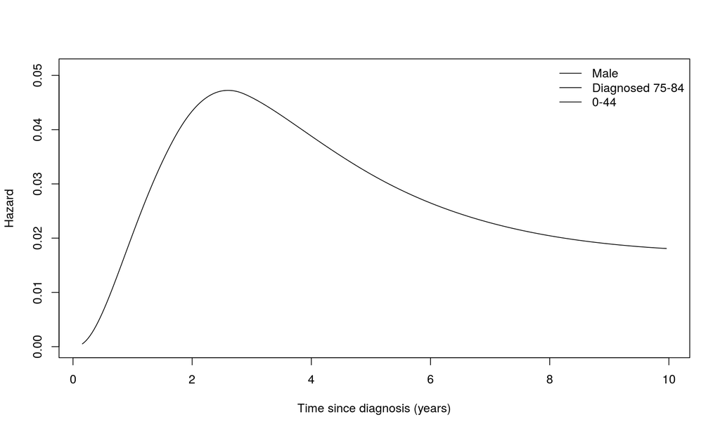

```r
## (i) Plot of baseline hazard with fpmh
sexs <- levels(melanoma$sex)
years <- levels(melanoma$year8594)
agegrps <- levels(melanoma$agegrp)
par(mfrow=c(1,1))
newdata1 <- data.frame(sex=sexs[1],year8594=years[1],agegrp2=0, agegrp3=0, agegrp4=0)
plot(fpmh,newdata=newdata1, xlab="Time since diagnosis (years)", ylab="Hazard",
     type="haz", ci=FALSE, ylim=c(0,0.051), rug=FALSE)
legend("topright", legend=c(sexs[1], years[1], agegrps[1]), lty=1, bty="n")
```

**(j)** Hazard ratios between age groups.

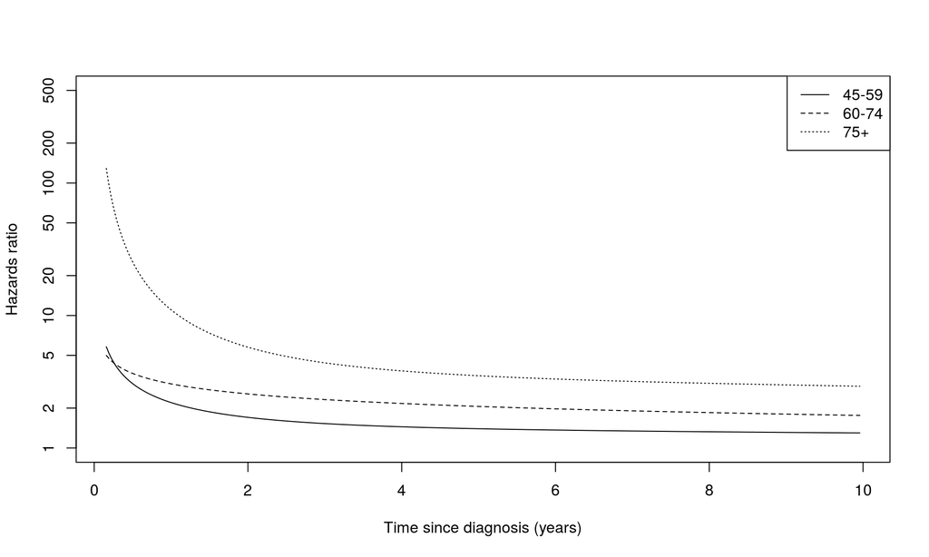

```r
plot(fpmh, newdata=data.frame(sex=sexs[1],year8594=years[1],agegrp2=0, agegrp3=0, agegrp4=0),
     type="hr", rug=FALSE, line.col=1, ci=FALSE,log="y", ylim=c(1,500), lty=1,
     exposed=function(data) transform(data,sex=sexs[1],year8594=years[1],agegrp2=1, agegrp3=0, agegrp4=0),
     xlab="Time since diagnosis (years)",ylab="Hazards ratio")
plot(fpmh, newdata=data.frame(sex=sexs[1],year8594=years[1],agegrp2=0, agegrp3=0, agegrp4=0),
     type="hr", rug=FALSE, line.col=1, ci=FALSE, add=T,log="y", lty=2,
     exposed=function(data) transform(data,sex=sexs[1],year8594=years[1],agegrp2=0, agegrp3=1, agegrp4=0),
     xlab="Time since diagnosis (years)",ylab="Hazards ratio")
plot(fpmh, newdata=data.frame(sex=sexs[1],year8594=years[1],agegrp2=0, agegrp3=0, agegrp4=0),
     type="hr", rug=FALSE, line.col=1, ci=FALSE,add=T,log="y", lty=3,
     exposed=function(data) transform(data,sex=sexs[1],year8594=years[1],agegrp2=0, agegrp3=0, agegrp4=1),
     xlab="Time since diagnosis (years)",ylab="Hazards ratio")
legend("topright", legend=agegrps[2:4], lty=1:3)
```

The hazard ratios decrease as a function of follow-up time. The hazard ratio is so high during the early years of follow-up because the hazard in the reference group is close to zero.

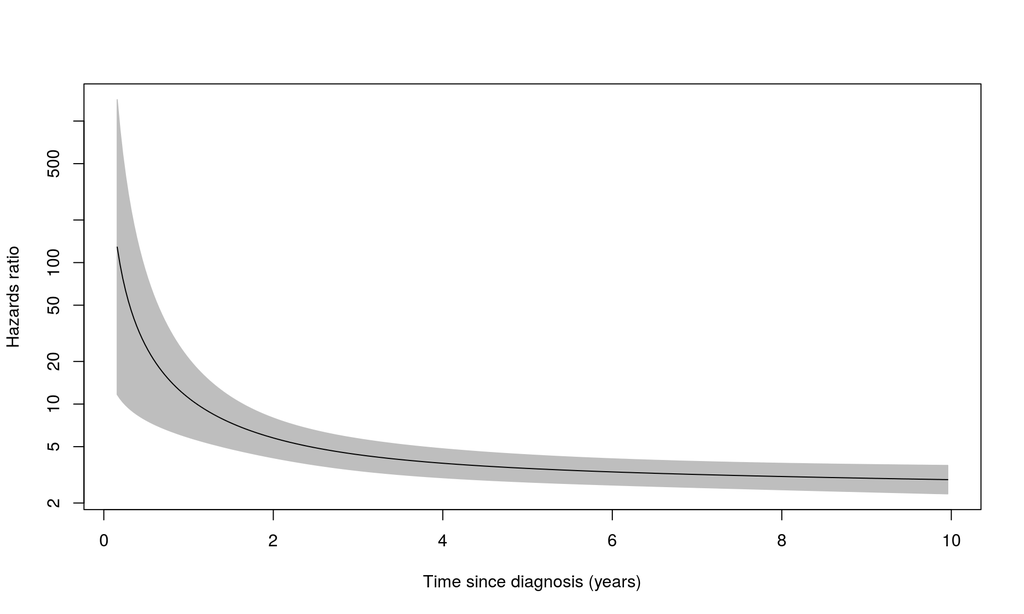

```r
plot(fpmh, newdata=data.frame(sex=sexs[1],year8594=years[1],agegrp2=0, agegrp3=0, agegrp4=0),
     type="hr", rug=FALSE, line.col=1, ci=T, log="y",
     exposed=function(data) transform(data,sex=sexs[1],year8594=years[1],agegrp2=0, agegrp3=0, agegrp4=1),
     xlab="Time since diagnosis (years)",ylab="Hazards ratio")
```

The hazard ratio for the oldest age group with a 95% confidence interval.

**(k)** The hazard difference for the oldest group.

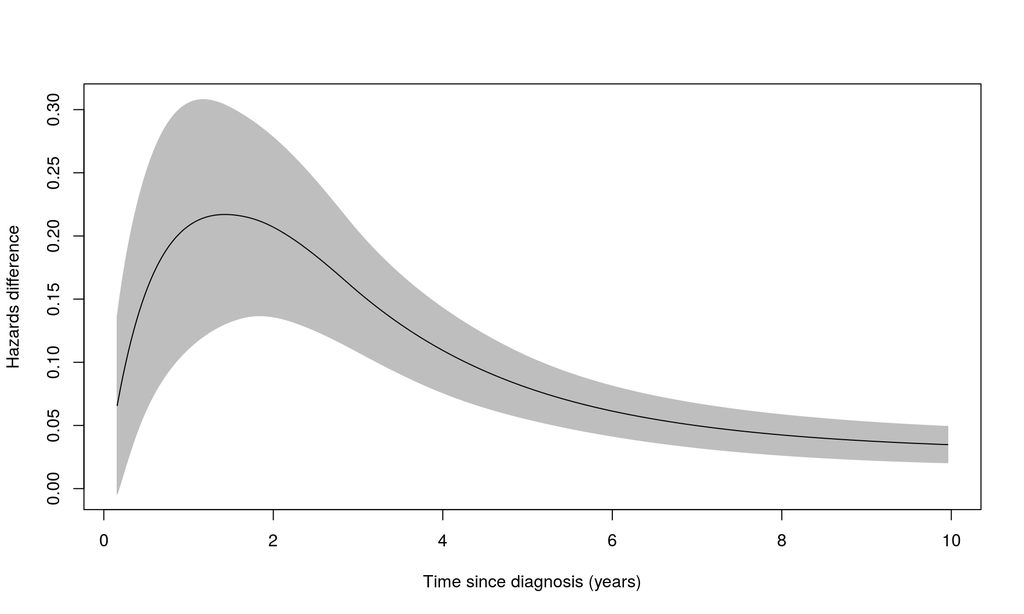

```r
plot(fpmh,newdata=data.frame(sex=sexs[1],year8594=years[1],agegrp2=0, agegrp3=0, agegrp4=0),
     type="hdiff", rug=FALSE, line.col=1, ci=T,
     exposed=function(data) transform(data,sex=sexs[1],year8594=years[1],agegrp2=0, agegrp3=0, agegrp4=1),
     xlab="Time since diagnosis (years)",ylab="Hazards difference")
```

Localised skin melanoma. Predicted difference in hazard rates (with a 95% confidence interval) for oldest age group from a fexible parametric model (other covariates are set to zero).

The hazard difference is small early on, despite the hazard ratio being large, because the underlying hazard is so low.

**(l)** The survival difference for the oldest group.

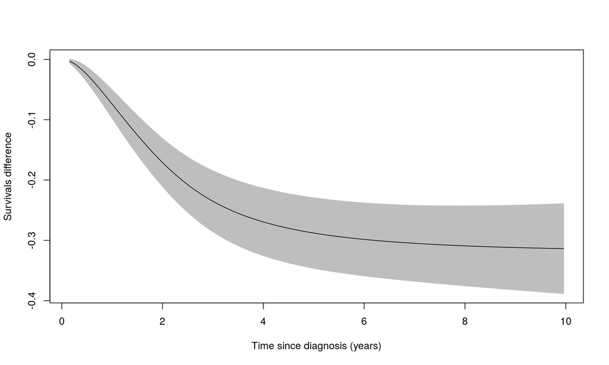

```r
plot(fpmh,newdata=data.frame(sex=sexs[1],year8594=years[1],agegrp2=0, agegrp3=0, agegrp4=0),
     type="sdiff", rug=FALSE, line.col=1, ci=T,
     exposed=function(data) transform(data, sex=sexs[1],year8594=years[1],agegrp2=0, agegrp3=0, agegrp4=1),
     xlab="Time since diagnosis (years)",ylab="Survivals difference")
```

**(m)** Fit models with 1, 2 and 3 df for time-dependent effect of age.

```r
aicc <- bicc <- beta <- se <- rep(1,3)
nevent <- sum(melanoma0$event)
BIC <- function(object, nknots){
  -2 * as.numeric(bbmle::logLik(object)) + log(nevent) * (1 + nknots)
}
for (i in 1:3 ) {
  fitdf <- stpm2(Surv(time,event) ~ sex + year8594 + agegrp2 + agegrp3 + agegrp4,
                  data=melanoma0, tvc=list(agegrp2 = i, agegrp3 = i, agegrp4 = i),
                  smooth.formula=~ nsx(log(time),df=4)  )
  aicc[i] <- AIC(fitaic)
  bicc[i] <- BIC(fitaic, i)
}
cbind(aicc=aicc, bicc=bicc)
```

```
##          aicc     bicc
## [1,] 8447.417 8447.151
## [2,] 8447.417 8454.018
## [3,] 8447.417 8460.884
```

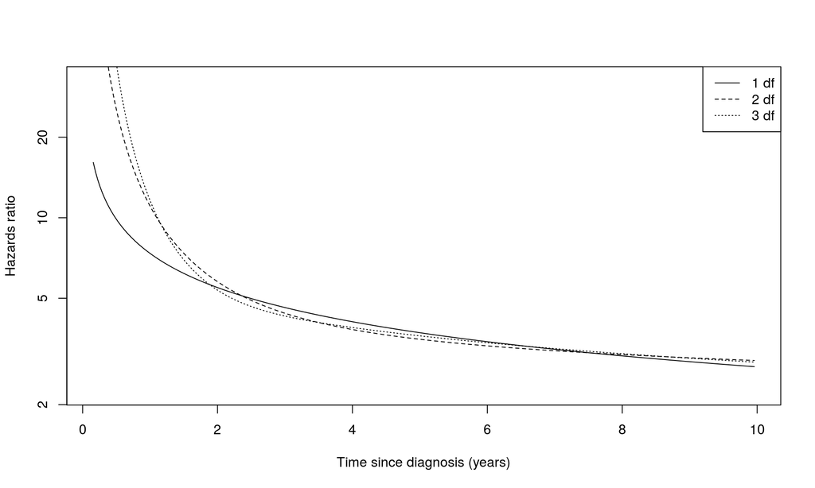

```r
## PLots with different df
fitdf1 <- stpm2(Surv(time,event) ~ sex + year8594 + agegrp2 + agegrp3 + agegrp4, data=melanoma0,
                tvc = list(agegrp2 = 1, agegrp3 = 1, agegrp4 = 1), smooth.formula=~ nsx(log(time),df=4))

plot(fitdf1, newdata = data.frame(sex=sexs[1], year8594=years[1], agegrp2=0, agegrp3=0, agegrp4=0),
     type="hr", rug=FALSE, line.col=1, ci=F, log="y", lty=1,
     exposed=function(data) transform(data, sex = sexs[1],year8594=years[1],
                                        agegrp2=0, agegrp3 = 0, agegrp4=1),
     xlab="Time since diagnosis (years)", ylab="Hazards ratio")

for (i in 2:3 ) {
    fitdf <- stpm2(Surv(time,event) ~ sex + year8594 + agegrp2 + agegrp3 + agegrp4,
                   data=melanoma0, tvc=list(agegrp2 = i, agegrp3 = i, agegrp4 = i),
                   smooth.formula=~ nsx(log(time),df=4))

    plot(fitdf, newdata=data.frame(sex=sexs[1],year8594=years[1],agegrp2=0, agegrp3=0, agegrp4=0),
         type="hr", rug=FALSE, line.col=1, ci=F, log="y", add=T, lty=i,
         exposed=function(data) transform(data, sex=sexs[1],year8594=years[1],agegrp2=0, agegrp3=0, agegrp4=1),
         xlab="Time since diagnosis (years)",ylab="Hazards ratio")
}
legend("topright", legend=c("1 df", "2 df", "3 df"), lty=1:3)
```